# The Comprehensive Guide to Conformal Statistical Inference

Uncertainty Quantification for Regression and Classification

Miguel Angel Luque Fernandez, PhD** Advanced Statistical Computing Lab *Department of Statistics and Operations Research* *Division of Biostatistics, Faculty of Medicine* *University of Granada, Spain* `mluquefe at ugr.es`

2026-02-04

# I. The Mathematical Core

The strength of Conformal Inference (CI) lies in its **Finite-Sample Validity**. Unlike asymptotic proofs that require $n \to \infty$, CI guarantees hold for any sample size $n$.

### 1. The Principle of Exchangeability

The fundamental assumption underlying Conformal Inference is that the data sequence $Z_1, \dots, Z_{n+1}$ (where $Z_i = (X_i, Y_i)$) is **exchangeable**.

**Definition:** A sequence is exchangeable if its joint probability distribution is invariant under permutations. This is a weaker (more general) assumption than being Independent and Identically Distributed (IID).

### 2. The Non-Conformity Score ($S$)

We define a score function $V(z, \mathcal{D})$ that measures how “unusual” a data point $z$ is relative to a dataset $\mathcal{D}$. Common score functions include:

**For Regression:**
$$S_i =
|y_i - \hat{\mu}(x_i)|$$

**For Classification:**
$$S_i
= 1 - \hat{\pi}(x_i)_{y_i}$$

**For Conformalized Quantile Regression (CQR):**
$$S_i = \max(\hat{q}_{low}(x_i) - y_i, \ y_i -
\hat{q}_{high}(x_i))$$

### 3. The Conformal Quantile

In the **Split Conformal** framework, we calculate scores on a calibration set of size $n$. To construct a $1-\alpha$ confidence interval, we define the threshold $\hat{q}$ as:

$$\hat{q} = \text{The } \frac{\lceil
(n+1)(1-\alpha) \rceil}{n} \text{ quantile of } \{S_1, \dots,
S_n\}$$

The $+1$ in the numerator is the critical **conformal correction**. It mathematically accounts for the fact that the unknown future point $Z_{n+1}$ is itself a member of the exchangeable sequence.

### 4. The Prediction Set

The prediction set for a new point $x_{n+1}$ is constructed by collecting all possible values of $y$ that result in a score no greater than the threshold $\hat{q}$:

$$C(x_{n+1}) = \{ y : V((x_{n+1}, y),
\mathcal{D}_{train}) \leq \hat{q} \}$$

**The Guarantee:** Under the sole assumption of exchangeability, it is mathematically proven that for any distribution and any model:

$$P(Y_{n+1} \in C(x_{n+1})) \geq 1 -
\alpha$$

# Theoretical Derivation: Why the $(n+1)$ Correction?

The validity of Conformal Inference relies on a simple yet profound observation about the **ranks** of exchangeable random variables.

### 1. The Symmetry Lemma

Assume we have $n$ calibration scores $\{S_1, \dots, S_n\}$ and one future test score $S_{n+1}$. If the underlying data points are exchangeable, then their corresponding non-conformity scores are also exchangeable.

By symmetry, the future score $S_{n+1}$ is equally likely to fall into any of the “bins” created by the sorted calibration scores. With $n$ calibration points, there are $n+1$ possible slots where $S_{n+1}$ could land:

1. Below the smallest score $S_{(1)}$
2. Between $S_{(1)}$ and $S_{(2)}$
3. …
4. Above the largest score $S_{(n)}$

Mathematically, for any $j \in \{1, \dots, n+1\}$:
$$P\left(
\text{Rank}(S_{n+1}) = j \right) = \frac{1}{n+1}$$

### 2. Defining the Coverage

We want to ensure that $S_{n+1}$ is not “too large.” Specifically, we want to find a threshold $\hat{q}$ such that $S_{n+1} \leq \hat{q}$ with probability at least $1-\alpha$.

If we sort our calibration scores as $S_{(1)} \leq S_{(2)} \leq \dots \leq S_{(n)}$, then $S_{n+1}$ is less than or equal to the $k$-th smallest calibration score $S_{(k)}$ if its rank is among the first $k$ positions:

$$P(S_{n+1} \leq S_{(k)}) =
\frac{k}{n+1}$$

### 3. Solving for $k$

To satisfy the coverage guarantee $P(S_{n+1} \leq \hat{q}) \geq 1-\alpha$, we set:
$$\frac{k}{n+1} \geq 1 -
\alpha$$

Solving for $k$:
$$k \geq (n+1)(1-\alpha)$$

Since $k$ must be an integer, we take the ceiling:
$$k = \lceil
(n+1)(1-\alpha) \rceil$$

### 4. The Final Threshold

The threshold $\hat{q}$ is therefore the $k$-th smallest value (the $(k/n)$-th quantile) of the calibration set:
$$\hat{q} =
\text{Quantile}\left( \{S_1, \dots, S_n\}, \frac{\lceil (n+1)(1-\alpha)
\rceil}{n} \right)$$

### Summary of the Logic

- **Without the $+1$:** We would be assuming the test point is not part of the distribution we are measuring.
- **With the $+1$:** We acknowledge that the test point is the $(n+1)$-th member of the sequence, making the probability bound exact rather than heuristic.

# Common Pitfalls and Implementation Risks

Even though Conformal Inference is “model-agnostic,” the validity of the $1-\alpha$ guarantee depends on strict procedural discipline. Below are the most frequent errors encountered in academic and industrial settings.

### 1. Data Leakage (Reusing Training Data)

The most common mistake is calculating non-conformity scores on the same data used to train the model ($\mu$).

- **The Error:** If you calculate scores on the training set, the residuals will be artificially small because the model has “memorized” those points.
- **The Consequence:** The threshold $\hat{q}$ will be too low, and the intervals will fail to cover new data points at the promised $1-\alpha$ rate.
- **The Fix:** Always use a “held-out” **Calibration Set** that the model has never seen during the training phase.

### 2. Violating Exchangeability (Distribution Shift)

Conformal Inference assumes that $(X_{1}, Y_{1}), \dots, (X_{n+1}, Y_{n+1})$ are exchangeable.

- **The Error:** Applying a threshold calculated on data from 2023 to data collected in 2026 where the underlying relationship has changed.
- **The Consequence:** If the test data is no longer “like” the calibration data, the $1-\alpha$ guarantee evaporates.
- **The Fix:** In time-series or shifting environments, use **Weighted Conformal Prediction** or **Online Conformal Prediction**, which give more weight to recent observations.

### 3. The “Average Coverage” Trap

It is a common misconception that 95% coverage means the model is 95% accurate for *every* individual.

- **The Error:** Assuming **Conditional Coverage** when you only have **Marginal Coverage**.
- **The Reality:** Standard Split Conformal guarantees that *on average* across the population, 95% of points will be covered. However, for a specific sub-group (e.g., a specific age range), the coverage might only be 80% while another group is 100%.
- **The Fix:** To improve local reliability, use **Locally Adaptive** methods like **CQR** (Conformalized Quantile Regression).

### 4. Selecting $\alpha$ After Seeing Results

- **The Error:** “P-hacking” the confidence level. Looking at the intervals and deciding to change $\alpha$ from 0.05 to 0.10 because the intervals look “too wide.”
- **The Consequence:** This violates the pre-specified nature of the guarantee.
- **The Fix:** Define the tolerance for error ($\alpha$) based on the risk profile of the application *before* running the calibration.

### 5. Over-interpreting the “Model-Agnostic” Property

- **The Error:** Thinking that because CI works with “any” model, the choice of model doesn’t matter.
- **The Reality:** While any model will give **valid** intervals (correct coverage), a poor model will give **useless** intervals (extremely wide or infinite sets).
- **The Fix:** Spend time tuning your underlying point model or quantile regressor. Conformal Inference makes a model **reliable**, but only good feature engineering makes it **efficient**.

### Summary Checklist for a Valid Implementation

1. Was the calibration set strictly separated from the training set?
2. Is the data reasonably exchangeable (no sudden temporal shifts)?
3. Was the $(n+1)$ finite-sample correction applied to the quantile?
4. Does the choice of score function ($S$) match the problem (Regression vs. Classification)?

# II. Part 1: Split-Conformal Regression

*Constant-width intervals for standard regression.*

### 1. Data Generation

We create data where the relationship is quadratic, but the noise is constant.

```r
set.seed(1)
n <- 1000
x <- runif(n, 0, 5)
y <- x^2 + rnorm(n, sd = 1.5) # Constant noise

# 50/50 Split for Training and Calibration
idx <- sample(1:n, n/2)
train_reg <- data.frame(x=x[idx], y=y[idx])
calib_reg <- data.frame(x=x[-idx], y=y[-idx])
```

### 2. Training and Score Calculation

```r
# Train model
rf_mu <- randomForest(y ~ x, data = train_reg)

# Calculate scores on calibration set
mu_calib <- predict(rf_mu, newdata = calib_reg)
scores_reg <- abs(calib_reg$y - mu_calib)

# Calculate Conformal Quantile (with finite sample correction)
alpha <- 0.10
n_cal <- length(scores_reg)
q_hat_reg <- quantile(scores_reg, probs = ceiling((n_cal + 1) * (1 - alpha)) / n_cal)
```

### 3. Visualization

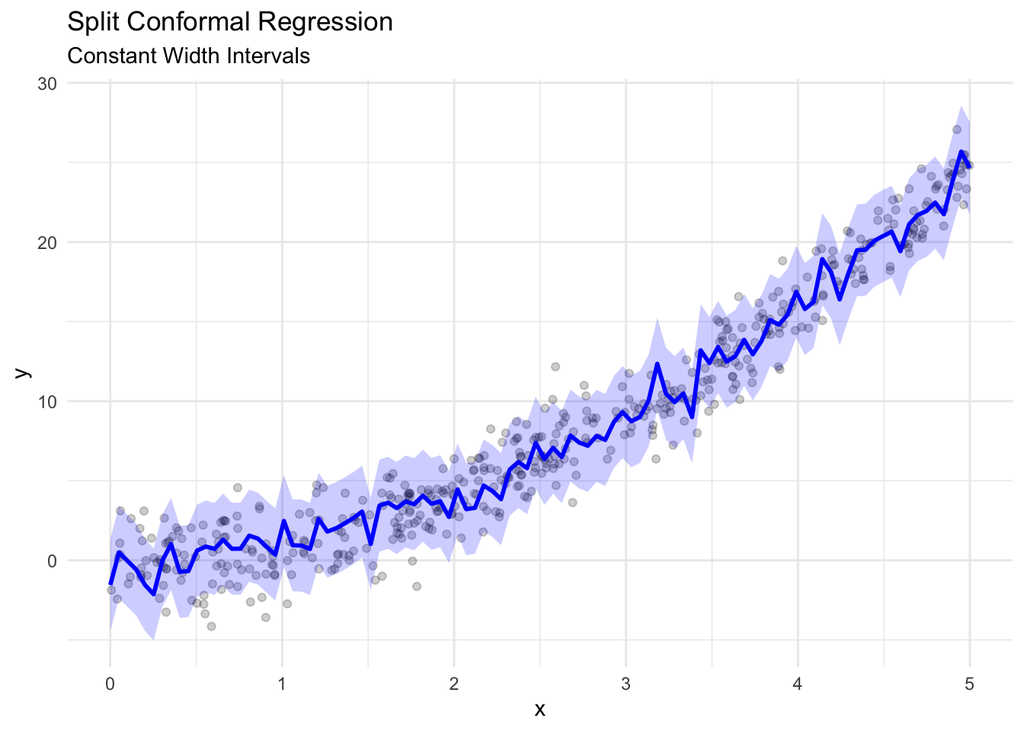

```r
test_x <- seq(0, 5, length.out = 100)
pred_y <- predict(rf_mu, newdata = data.frame(x = test_x))

ggplot() +
  geom_point(data = calib_reg, aes(x, y), alpha = 0.2) +
  geom_line(aes(test_x, pred_y), color = "blue", size = 1) +
  geom_ribbon(aes(x = test_x, ymin = pred_y - q_hat_reg, ymax = pred_y + q_hat_reg),
              fill = "blue", alpha = 0.2) +
  labs(title = "Split Conformal Regression", subtitle = "Constant Width Intervals") +
  theme_minimal()
```

# III. Part 2: Conformalized Quantile Regression (CQR)

*Adaptive-width intervals for heteroscedastic data.*

### 1. Data with Variable Noise

```r
# Noise increases with x
y_het <- x^2 + rnorm(n, sd = 0.5 * x)
train_cqr <- data.frame(x=x[idx], y=y_het[idx])
calib_cqr <- data.frame(x=x[-idx], y=y_het[-idx])
```

### 2. The CQR Score

We train a model to predict the 5th and 95th percentiles and calibrate the “signed distance” to the true value.

```r
# Train Quantile Forest
qrf <- quantregForest(x = as.matrix(train_cqr$x), y = train_cqr$y)

# Get calibration quantiles
cal_q <- predict(qrf, newdata = as.matrix(calib_cqr$x), what = c(0.05, 0.95))

# CQR Score: distance outside predicted range
scores_cqr <- pmax(cal_q[,1] - calib_cqr$y, calib_cqr$y - cal_q[,2])
q_hat_cqr <- quantile(scores_cqr, probs = ceiling((n_cal + 1) * (1 - alpha)) / n_cal)
```

### 3. Adaptive Visualization

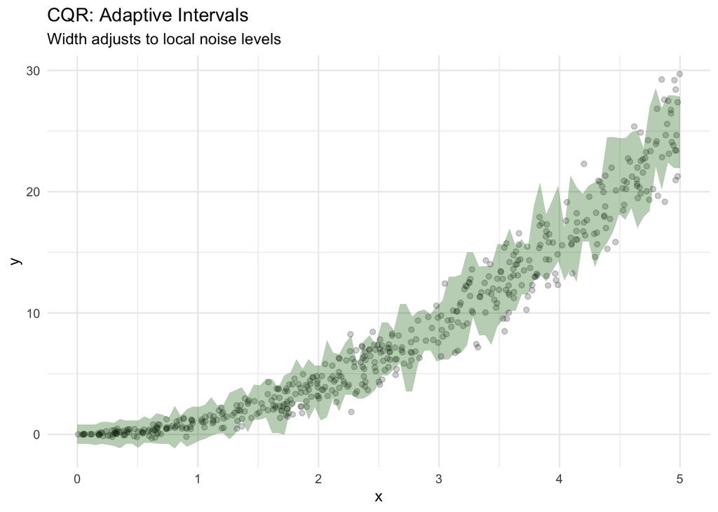

```r
test_q <- predict(qrf, newdata = as.matrix(test_x), what = c(0.05, 0.95))

ggplot() +
  geom_point(data = calib_cqr, aes(x, y), alpha = 0.2) +
  geom_ribbon(aes(x = test_x, ymin = test_q[,1] - q_hat_cqr, ymax = test_q[,2] + q_hat_cqr),
              fill = "darkgreen", alpha = 0.3) +
  labs(title = "CQR: Adaptive Intervals", subtitle = "Width adjusts to local noise levels") +
  theme_minimal()
```

Adaptive intervals widen where noise is higher, demonstrating the strength of CQR in heteroscedastic settings. Here we get the values for new predicted points:

```r
new_points <- data.frame(x = c(1, 2, 3, 4))
pred_cqr <- predict(qrf, newdata = as.matrix(new_points$x), what = c(0.05, 0.95))
cqr_intervals <- data.frame(
  Lower = pred_cqr[,1] - q_hat_cqr,
  Upper = pred_cqr[,2] + q_hat_cqr
)
print(cqr_intervals)
```

```
##        Lower     Upper
## 1 -0.6801017  2.273845
## 2  1.1458447  5.675685
## 3  6.0120175 10.998667
## 4 14.2773698 20.499245
```

# IV. Part 3: Conformal Classification

*Predicting statistically valid ‘Sets’ of labels.*

### 1. The Classifier

Using the `iris` dataset with added noise to demonstrate uncertainty.

```r
data(iris)
iris_n <- iris
iris_n[,1:4] <- iris_n[,1:4] + rnorm(150*4, sd = 1.0) # Add noise

# Split
c_idx <- sample(1:150, 100)
c_train <- iris_n[c_idx, ]
c_calib <- iris_n[-c_idx, ]

# Fit Model
class_model <- multinom(Species ~ ., data = c_train, trace = FALSE)
```

### 2. Calibration and Set Generation

```r
cal_probs <- predict(class_model, newdata = c_calib, type = "probs")

# Probability of actual correct labels
true_probs <- sapply(1:nrow(c_calib), function(i) cal_probs[i, as.character(c_calib$Species[i])])
scores_class <- 1 - true_probs

q_hat_class <- quantile(scores_class, probs = ceiling((nrow(c_calib)+1)*0.9)/nrow(c_calib))

# Create sets for new points: all classes where P(class) >= 1 - q_hat
test_probs <- predict(class_model, newdata = head(iris_n), type = "probs")
pred_sets <- apply(test_probs, 1, function(p) names(p)[p >= (1 - q_hat_class)])

print(pred_sets)
```

```
## $`1`
## [1] "setosa"
##
## $`2`
## [1] "setosa"
##
## $`3`
## [1] "setosa"
##
## $`4`
## [1] "setosa"
##
## $`5`
## [1] "setosa"
##
## $`6`
## [1] "setosa"     "versicolor"
```

### 3. Example with clase 0=alive, 1=dead

```r
# Simulated binary classification data
set.seed(42)
n_bin <- 200
x1 <- rnorm(n_bin)
x2 <- rnorm(n_bin)
y_bin <- ifelse(x1 + x2 + rnorm(n_bin) > 0, 1, 0)
bin_data <- data.frame(x1 = x1, x2 = x2, y = as.factor(y_bin))
# Split
bin_idx <- sample(1:n_bin, n_bin * 0.7)
bin_train <- bin_data[bin_idx, ]
bin_calib <- bin_data[-bin_idx, ]
# Fit logistic regression
bin_model <- glm(y ~ x1 + x2, data = bin_train, family = binomial)
# Calibration
bin_calib_probs <- predict(bin_model, newdata = bin_calib, type = "response")
bin_true_probs <- ifelse(bin_calib$y == 1, bin_calib_probs, 1 - bin_calib_probs)
bin_scores <- 1 - bin_true_probs
bin_q_hat <- quantile(bin_scores, probs = ceiling((nrow(bin_calib)+1)*0.9)/nrow(bin_calib))
# Define new test points
new_bin_points <- data.frame(x1 = c(0.5, -0.5), x2 = c(0.5, -0.5))
# Generate probabilities for the positive class (Class "1")
new_bin_probs <- predict(bin_model, newdata = new_bin_points, type = "response")
# Construct Prediction Sets
# A class is included if its probability is at least (1 - q_hat)
bin_pred_sets <- lapply(new_bin_probs, function(p) {
  classes <- c()
  # Check Class "1"
  if (p >= (1 - bin_q_hat)) {
    classes <- c(classes, "1")
  }
  # Check Class "0"
  if ((1 - p) >= (1 - bin_q_hat)) {
    classes <- c(classes, "0")
  }
  return(classes)
})
# Display the results
names(bin_pred_sets) <- paste0("Point_", 1:length(bin_pred_sets))
print(bin_pred_sets)
```

```
## $Point_1
## [1] "1"
##
## $Point_2
## [1] "0"
```

### 4. Empirical Evaluation of Binary Conformal Sets

```r
# Generate test data and probabilities
test_bin_probs <- predict(bin_model, newdata = bin_calib, type = "response")
# Construct sets for the entire test set
test_pred_sets <- lapply(test_bin_probs, function(p) {
  classes <- c()
  if (p >= (1 - bin_q_hat)) classes <- c(classes, "1")
  if ((1 - p) >= (1 - bin_q_hat)) classes <- c(classes, "0")
  return(classes)
})

# Calculate Empirical Coverage
# Check if the actual true label (test_df$y) is inside the prediction set
is_covered <- sapply(1:nrow(bin_calib), function(i) {
  as.character(bin_calib$y[i]) %in% test_pred_sets[[i]]
})

empirical_coverage <- mean(is_covered)

# Calculate Average Set Size (Efficiency)
set_sizes <- sapply(test_pred_sets, length)
avg_set_size <- mean(set_sizes)

# Summary Table
evaluation_summary <- data.frame(
  Metric = c("Target Coverage", "Empirical Coverage", "Avg. Set Size", "Empty Sets (%)"),
  Value = c(
    1 - alpha,
    empirical_coverage,
    avg_set_size,
    mean(set_sizes == 0) * 100
  )
)

print(evaluation_summary)
```

```
##               Metric     Value
## 1    Target Coverage 0.9000000
## 2 Empirical Coverage 0.9166667
## 3      Avg. Set Size 1.3333333
## 4     Empty Sets (%) 0.0000000
```

Visualization of Set Sizes vs. Predicted Probabilities:

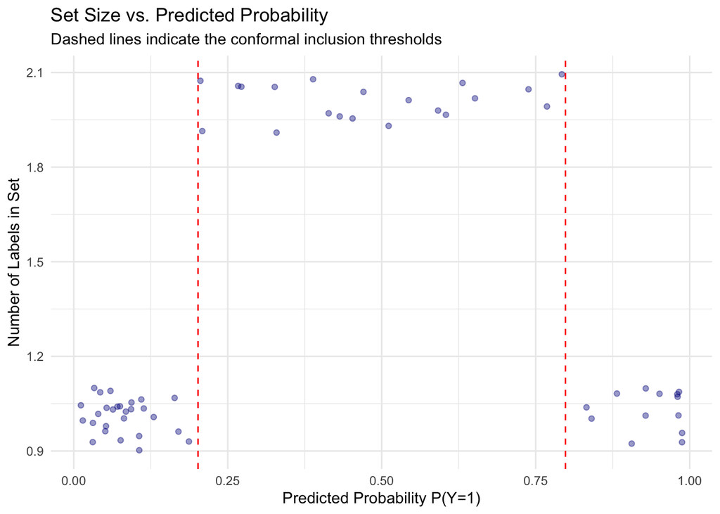

```r
# Visualize Set Size vs. Probability
# This helps students see that ambiguity (p near 0.5) leads to larger sets
plot_df <- data.frame(prob = test_bin_probs, size = set_sizes)
ggplot(plot_df, aes(x = prob, y = size)) +
  geom_jitter(height = 0.1, alpha = 0.4, color = "darkblue") +
  geom_vline(xintercept = c(1 - bin_q_hat, bin_q_hat), linetype = "dashed", color = "red") +
  labs(title = "Set Size vs. Predicted Probability",
       subtitle = "Dashed lines indicate the conformal inclusion thresholds",
       x = "Predicted Probability P(Y=1)", y = "Number of Labels in Set") +
  theme_minimal()
```

# V. Summary and Conclusion

The following table summarizes the three main Conformal Inference frameworks covered in this module:

| Method | Output Type | Score Function ($S$) | Best Used When… |
| --- | --- | --- | --- |
| **Split Regression** | Constant Interval | $\|y_i - \hat{\mu}(x_i)\|$ | Noise is uniform (homoscedastic). |
| **CQR** | Adaptive Interval | $\max(\hat{q}_L - y_i, y_i - \hat{q}_H)$ | Noise varies by $X$ (heteroscedastic). |
| **Classification** | Prediction Set | $1 - \hat{\pi}(x_i)_{y_{true}}$ | High-stakes categorical decisions. |

**The power** of Conformal Inference lies in its **honesty**. If the model is bad, the intervals/sets will simply get larger, but they will never lie about their coverage. Regardless of which model or score function you choose, the following mathematical guarantee holds:

### 1. The Probability Bound

Given a user-defined error tolerance $\alpha$ (e.g., $\alpha = 0.10$ for 90% confidence), and assuming the data is **exchangeable**, the prediction set $C(X_{n+1})$ satisfies:

$$P(Y_{n+1} \in C(X_{n+1})) \geq 1 -
\alpha$$

### 2. Interpreting the Bound

- **Finite Sample:** This is not an “asymptotic” result. It works for $n=50$ just as well as $n=50,000$.
- **Model Agnostic:** The guarantee holds even if your underlying model ($\hat{\mu}$ or $\hat{\pi}$) is biased or poorly tuned.
- **Reliability vs. Efficiency:** While the **coverage** (1 - $\alpha$) is always guaranteed, a better model will result in **tighter** (more efficient) intervals or smaller prediction sets.

### 3. Key Requirement: Exchangeability

The only major mathematical requirement is that your calibration data and your new test data come from the same process. **Note:** If the world changes (distribution shift), the guarantee may no longer hold unless you use “Weighted” or “Adaptive” Conformal methods.

# VI. Primary Academic References

These references are categorized by their role in the development of the field.

#### The Foundations (The “Vovk” Era)

1.**Vovk, V., Gammerman, A., & Shafer, G. (2005).** *Algorithmic Learning in a Random World*. Springer.

#### Modern Split-Conformal & Regression

2.**Lei, J., G’Sell, M., Rinaldo, A., Tibshirani, R. J., & Wasserman, L. (2018).** “Distribution-free predictive inference for regression.” *Journal of the American Statistical Association*.

3.**Romano, Y., Patterson, E., & Candès, E. (2019).** “Conformalized Quantile Regression.” *Advances in Neural Information Processing Systems (NeurIPS)*.

#### Modern Classification & Sets

4.**Angelopoulos, A. N., & Bates, S. (2021).** “A Gentle Introduction to Conformal Prediction and Distribution-Free Uncertainty Quantification.” *arXiv preprint*.

5.**Sadinle, M., Lei, J., & Wasserman, L. (2019).** “Least ambiguous set-valued classifiers with bounded error levels.” *Journal of the American Statistical Association*.

#### Robustness & Distribution Shift

6.**Tibshirani, R. J., Foygel Barber, R., Candès, E., & Ramdas, A. (2019).** “Conformal Prediction Under Covariate Shift.” *Advances in Neural Information Processing Systems (NeurIPS)*.